# Performance Machine Learning

An analysis on using wearables to predict level of performance

16 February 2016

## Summary

One thing that people regularly do is quantify how much of a particular activity they do, but they rarely quantify how well they do it.

In this project, the goal will be to use data from accelerometers on the belt, forearm, arm, and dumbell of 6 participants, as described in paper Qualitative Activity Recognition of Weight Lifting Exercises (Velloso, E et al. 2013), to train a random forest model capable of predict wheter the exercise in being realized in the correct way, or fall in one of the typified error classes.

## 1. Data Overview

```r
dim(training)
```

```
## [1] 19622   160
```

```r
table(nadt$na_cont)
```

```
##
##     0 19216 19217 19218 19220 19221 19225 19226 19227 19248 19293 19294
##    60    67     1     1     1     4     1     4     2     2     1     1
## 19296 19299 19300 19301 19622
##     2     1     4     2     6
```

The dataset contains 160 columns, but a great number of them (100) contains mostly (more than 97.93% of rows) “NA” or “#DIV/0!” values, so we will remove before any other action is taken. After that, we check for near zero variance predictors, removing 1 additional variables.

## 2. Feature selection

First, we remove the variables that are related to the specific metodology of the data gathering (such as user_name, row id, window information and timestamp related info), as we want to try to fit the random forest with the minimal information about the subject and, being the “classe” outcome ordered in alphabetical order, sequences have a clear relation with the outcome, but wont be realistic in any other type of sample data.

As next step, we check the correlation of the remaining variables, finding that there are 8 highly correlated variables (cor > 0.85), as can be seen in the plot below:

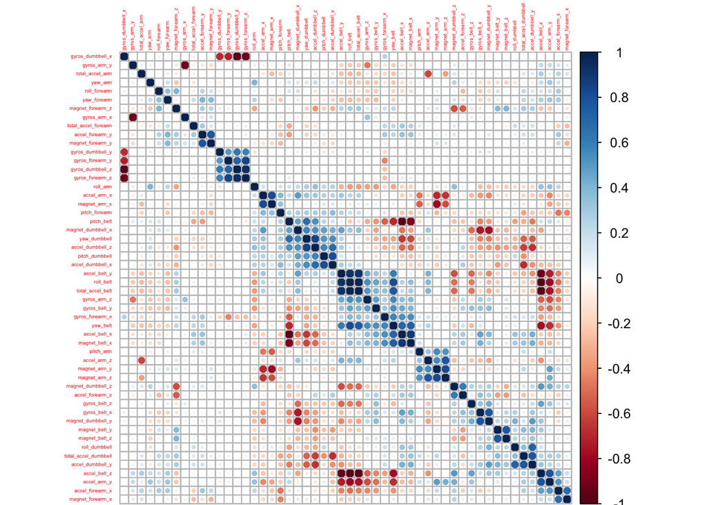

## 3. Training the model

As already stated, we agree with the original authors of the paper (Velloso, E et al. 2013) that the random forest should probably perform quite well on this classification problem, so we use caret package to extract a train index for only half of the observations, that will allow to have a quite large remaining set to be used as validation set. A cross validation on 10 folders is set as trainControl method to reduce bias in sample selecction.

The final random forest uses 23 variables in its best tune. For further information, the R model dump can be downloaded from this link: Download Ranfom Forest Model

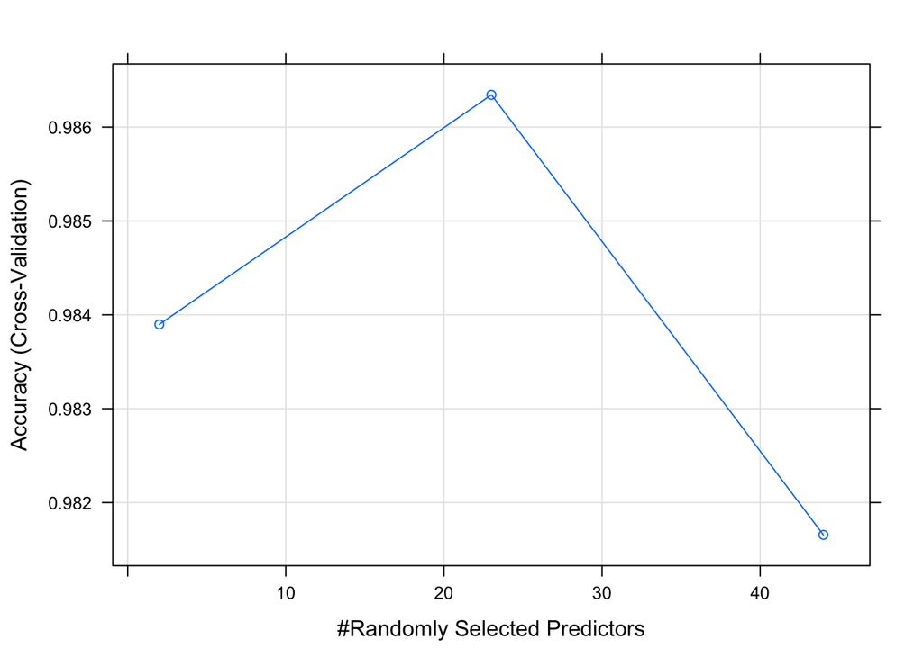

```r
plot(rf)
```

The prediction for the half of the data set that was not used in training has an accuracy of 98.99%. The confusion matrix shows that sensiviy and specificity for class “A” (exercises done in the proper way) are greater than 99.75%, and a balanced accuracy of 99.77%. Simmilarly, performance indicators for error type classes have also very high values.

|  | A | B | C | D | E |
| --- | --- | --- | --- | --- | --- |
| A | 2783 | 15 | 0 | 0 | 0 |
| B | 6 | 1872 | 19 | 0 | 1 |
| C | 0 | 11 | 1687 | 32 | 0 |
| D | 0 | 0 | 5 | 1574 | 7 |
| E | 1 | 0 | 0 | 2 | 1795 |

|  | Sensitivity | Specificity | Pos Pred Value | Neg Pred Value | Prevalence | Detection Rate | Detection Prevalence | Balanced Accuracy |
| --- | --- | --- | --- | --- | --- | --- | --- | --- |
| Class: A | 0.9974910 | 0.9978632 | 0.9946390 | 0.9990017 | 0.2844037 | 0.2836901 | 0.2852192 | 0.9976771 |
| Class: B | 0.9863014 | 0.9967139 | 0.9863014 | 0.9967139 | 0.1934760 | 0.1908257 | 0.1934760 | 0.9915076 |
| Class: C | 0.9859731 | 0.9946907 | 0.9751445 | 0.9970297 | 0.1744139 | 0.1719674 | 0.1763507 | 0.9903319 |
| Class: D | 0.9788557 | 0.9985369 | 0.9924338 | 0.9958658 | 0.1639144 | 0.1604485 | 0.1616718 | 0.9886963 |
| Class: E | 0.9955630 | 0.9996253 | 0.9983315 | 0.9990015 | 0.1837920 | 0.1829766 | 0.1832824 | 0.9975941 |

It seems that the trained model can predict with an outstanding accuracy, although it is known the tendence of the random forests to overfit, so it could be expected worse accuracy levels when new people exercises are classified with this model.

## 4. Prediction

Using the model to predict the class for the pml-testing dataset we get the following values:

```r
predict(rf,testing)
```

```
##  [1] B A B A A E D B A A B C B A E E A B B B
## Levels: A B C D E
```

## 5. References

Velloso, E, Bulling, A., Gellersen, H., Ugulino, W., and Fuks, H. 2013. “Qualitative Activity Recognition of Weight Lifting Exercises.” *Proceedings of 4th International Conference in Cooperation with SIGCHI (Augmented Human ’13)*. ACM SIGCHI. http://groupware.les.inf.puc-rio.br/public/papers/2013.Velloso.QAR-WLE.pdf.